# Shiny App: Holt-Winters Time Series

12/5/2017

## Agenda

- Introduction
- Holt-Winters Time Series
- Example of Product Sales and Advertising Expenditures

## Introduction

This is a student project for Coursera course **Data Product**. The project is to deploy a shiny app that takes inputs from user interface in *ui.R* and generate statistical outputs from *server.R*. The application is launched at the platform from RStudio shinyapss.io, the source code is stored at github, and the presentation documentation is published on Rpub.

The dataset that I chose was from data library, and it contains advertising cost and sales data of a specific product in the past 36 months.

The materials can be found in:

Web app: https://yuqi.shinyapps.io/dataproduct_shiny/

GitHub Repo: https://github.com/Yukiwang77/dataproduct_shiny

## Holt-Winters Time Series

The Holt-Winters seasonal method comprises the forecast equation and three smoothing equations — one for the level, one for trend, and one for the seasonal component, with smoothing parameters \(\alpha\), \(\beta\) and \(\gamma\).

Properties:  
1.\(\alpha\) \(\subset\) (0, 1], \(\beta\) \(\subset\) [0,1], and \(\gamma\) \(\subset\) [0,1].  
2. A small value of \(\alpha\), \(\beta\) and \(\gamma\) means that the older values in time series data are weighted more heavily.  
3. Values of \(\alpha\), \(\beta\) and \(\gamma\) near 1.0 mean that the latest value has more weight.

## Holt-Winters Time Series Demo

To demo the shiny app, let's set paramters as below for both advertising and sales and call the function in R to generate forecast till EOY 2018.

\(\alpha\) = 0.85 \(\beta\) = 0.5 \(\gamma\) = 0.75

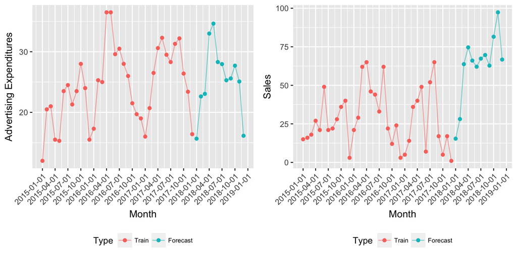